# Qualify rxode2 model against NONMEM

```r
library(nonmem2rx)

# First we need the location of the nonmem control stream Since we are running an example, we will use one of the built-in examples in `nonmem2rx`
ctlFile <- system.file("mods/cpt/runODE032.ctl", package="nonmem2rx")
# You can use a control stream or other file. With the development
# version of `babelmixr2`, you can simply point to the listing file

mod <- nonmem2rx(ctlFile, lst=".res", save=FALSE, determineError=FALSE)
```

[output not shown]

### Comparing differences between `NONMEM` and `rxode2`

You may wish to see where the differences in predictions are between NONMEM and rxode2.

The `rxode2` generated outputs are compared with the `NONMEM` generated outputs for the following items:

- **Population Predictions:** this shows if the model translation is adequate to simulate general trends; This will validate structural model’s population parameters coupled with the model structure.
- **Individual Predictions:** this shows if the model translation is able to replicate the same values over all the subjects within the modeling data-set. This validates the model can reproduce the between subject variability observed in the study.
- **Individual Weighted Residuals:** this is one step further than the individual parameter validation, it couples the individual predictions, the observations and the residual specification to generate the individual weighted residuals. Since you can [modify the residual specification to create a nlmixr2-compatible model](https://nlmixr2.github.io/nonmem2rx/articles/convert-nlmixr2.html), this step is important to make sure the residual specification is the same.

**Note:** the only part that is not validated with these three metrics is the between subject covariance matrix, `omega`. We assume this is correct as long as it is read in correctly.

## Comparing numerically

If you want numerical differences, you can also get these from the modified returned `ui` object. For the rtol, atol as follows you have:

```r
mod$iwresAtol
```

```
#>         50%
#> 3.64871e-06
```

```r
mod$iwresRtol
```

```
#>          50%
#> 8.987887e-06
```

```r
mod$ipredAtol
```

```
#>        50%
#> 0.00166826
```

```r
mod$ipredRtol
```

```
#>          50%
#> 6.430677e-06
```

```r
mod$predAtol
```

```
#>          50%
#> 6.406839e-06
```

```r
mod$predAtol
```

```
#>          50%
#> 6.406839e-06
```

You can see they do not exactly match but are very close (I would say they validate). However you can explore these difference further if you wish by looking at the `ipredCompare` and `predCompare` datasets:

```r
head(mod$iwresCompare)
```

```
#>   ID TIME nonmemIWRES      IWRES
#> 1  1 0.25    -0.73154 -0.7315464
#> 2  1 0.50     1.86670  1.8666563
#> 3  1 0.75    -1.26860 -1.2685789
#> 4  1 1.00     0.44442  0.4444172
#> 5  1 1.50     0.55470  0.5546978
#> 6  1 2.00     0.35351  0.3535035
```

```r
head(mod$ipredCompare)
```

```
#>   ID TIME nonmemIPRED    IPRED
#> 1  1 0.25      1215.4 1215.358
#> 2  1 0.50      1191.9 1191.924
#> 3  1 0.75      1169.2 1169.164
#> 4  1 1.00      1147.1 1147.057
#> 5  1 1.50      1104.7 1104.721
#> 6  1 2.00      1064.8 1064.759
```

```r
head(mod$predCompare)
```

```
#>   ID TIME nonmemPRED     PRED
#> 1  1 0.25     1750.3 1750.290
#> 2  1 0.50     1699.8 1699.834
#> 3  1 0.75     1651.3 1651.349
#> 4  1 1.00     1604.8 1604.752
#> 5  1 1.50     1516.9 1516.913
#> 6  1 2.00     1435.7 1435.723
```

In these cases you can see that NONMEM seems to round the values for the output (the rounding rules are based on the `FORMAT` option), but rxode2 seems to keep the entire number.

Note this is the **observation data only** that is compared. Dosing predictions are excluded from these comparisons.

You can also explore the NONMEM input dataset that was used to make the validation predictions (dosing and observations) by the `$nonmemData` item:

```r
head(mod$nonmemData) # with nlme loaded you can also use getData(mod)
```

```
#>   ID TIME     DV   LNDV MDV    AMT EVID   DOSE   V1I  CLI   QI   V2I SSX IIX SD
#> 1  1 0.00    0.0 0.0000   1 120000    1 120000 101.5 3.57 6.99 59.19  99   0  1
#> 2  1 0.25 1040.7 6.9476   0      0    0 120000 101.5 3.57 6.99 59.19  99   0  1
#> 3  1 0.50 1629.0 7.3957   0      0    0 120000 101.5 3.57 6.99 59.19  99   0  1
#> 4  1 0.75  877.8 6.7774   0      0    0 120000 101.5 3.57 6.99 59.19  99   0  1
#> 5  1 1.00 1247.2 7.1286   0      0    0 120000 101.5 3.57 6.99 59.19  99   0  1
#> 6  1 1.50 1225.1 7.1107   0      0    0 120000 101.5 3.57 6.99 59.19  99   0  1
#>   CMT
#> 1   1
#> 2   1
#> 3   1
#> 4   1
#> 5   1
#> 6   1
```

## Comparing visually

The easiest way to visually compare the differences is by the plot method:

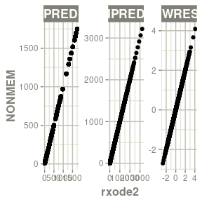

```r
plot(mod) # for general plot
```

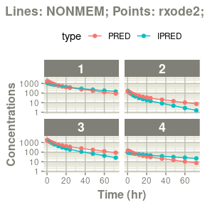

```r
# you can also see individual comparisons
plot(mod, log="y", ncol=2, nrow=2,
     xlab="Time (hr)", ylab="Concentrations",
     page=1)
```

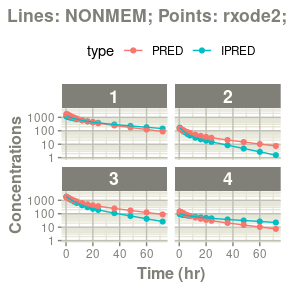

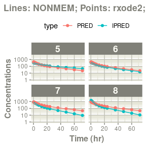

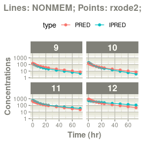

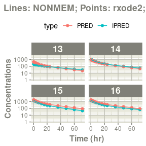

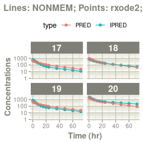

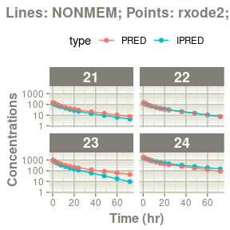

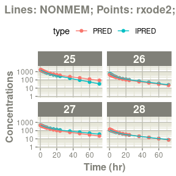

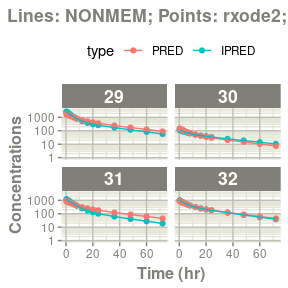

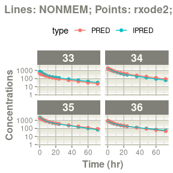

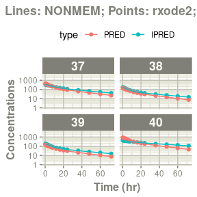

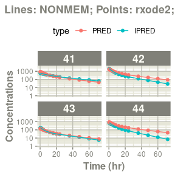

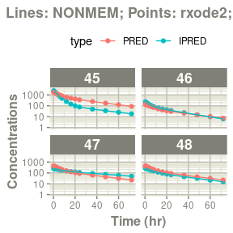

[18 more figures not shown]

```r
# If you want all pages you could use:
#
plot(mod, log="y", ncol=2, nrow=2,
     xlab="Time (hr)", ylab="Concentrations",
     page=TRUE)
```

## Notes on validation

The validation of the model uses the best data available for NONMEM estimates. This is:

- `theta` or population parameters
- `eta` or individual parameters

The `omega` and `sigma` matrices are captured. When the nlmixr2 model is fully qualified, the `IWRES` validation ensures the residual errors are specified correctly. Otherwise `omega` and `sigma` values do not contribute to the validation. Also the overall covariance is captured, but not used in the validation.